# Coursework Report

*N* removed NAs: 4

*N* removed <18: 19

**Correct typo age:** 18

*N* total clean: 145

| Group | *N* | *M*<sub>age</sub> | % green |
| --- | --- | --- | --- |
| Control | 74 | 20.64 | 34.68 |
| Experim | 71 | 20.63 | 49.30 |

| Gender | *N* | *M*<sub>age</sub> | % green |
| --- | --- | --- | --- |
| Male | 62 | 20.69 | 41.40 |
| Female | 57 | 20.46 | 42.11 |
| Other | 26 | 20.88 | 42.31 |

**Main analysis results**

**car:**  
χ<sup>2</sup>(1) = 0, *p* = .968

**cleaner:**  
χ<sup>2</sup>(1) = 3.59, *p* = .058

**dishwasher:**  
χ<sup>2</sup>(1) = 8.48, *p* = .004

[interactive chart not shown]

[figure not shown]

[interactive chart not shown]

# Coursework Report

Analysing Data, Spring 2020

# Method

## Participants

Table 1 *Descriptive statistics by Gender*

[output not shown]

Table 2 *Descriptive statistics by Condition*

[output not shown]

## Design

Research Question; *“Why do people choose to buy ‘green’ products.”*

Conceptual Hypothesis; *“Buying green products is related to status motives.”* (Griskevicius, 2010)

Each variable has been operationalised in the following ways; Firstly, the variable of participants’ ages in years, and this variable was a numeric. Age was measured on a numerical scale, and ages above 18 years were accepted and included, the higher the numeric, the older the participant is. The second variable included was the gender of participants; a factor variable. This variable was not created, and was measured using levels, with participants being able to choose one of three options: ‘Male’, ‘Female’ and ‘Other’. The next variable in this study, was the between-participant-conditions, of which each participant was assigned one of two options at random. This variable was created and measured as a factor. Those in the experimental group were given a high-status story to read that successfully elicited status motives (Griskevicius, 2010), whereas control participants read a neutral-story that did not elicit such motives.

The fourth variable in this research is the selection that the participant’s each made. With options between the luxury option, or the green option. This variable was also created as and is a factor. Finally, the last variable in this research is the product that the participant’s selected. The options in this variable indicate the choices that participants made between a car, cleaner, or dishwasher, and this is also a factor variable. This variable was created by providing participant’s with the options to buy one of these products.

Operational Hypothesis; *“People in the high-status experimental condition will choose green products more frequently that those in the control condition.”* (Griskevisius, 2010) I will complete a chi-squared test, to test these hypotheses’ significance.

# Results

Variables were operationalised as whether reading a high-status (experimental) or neutral-status (control) story was associated with the frequency with which green products were purchased over non-green, luxury products.

Table 4 *Observed Frequency of Green or Non-Green Cars Bought, by Condition*

|  | Control | Experimental |
| --- | --- | --- |
| luxury | 44 | 41 |
| green | 30 | 30 |

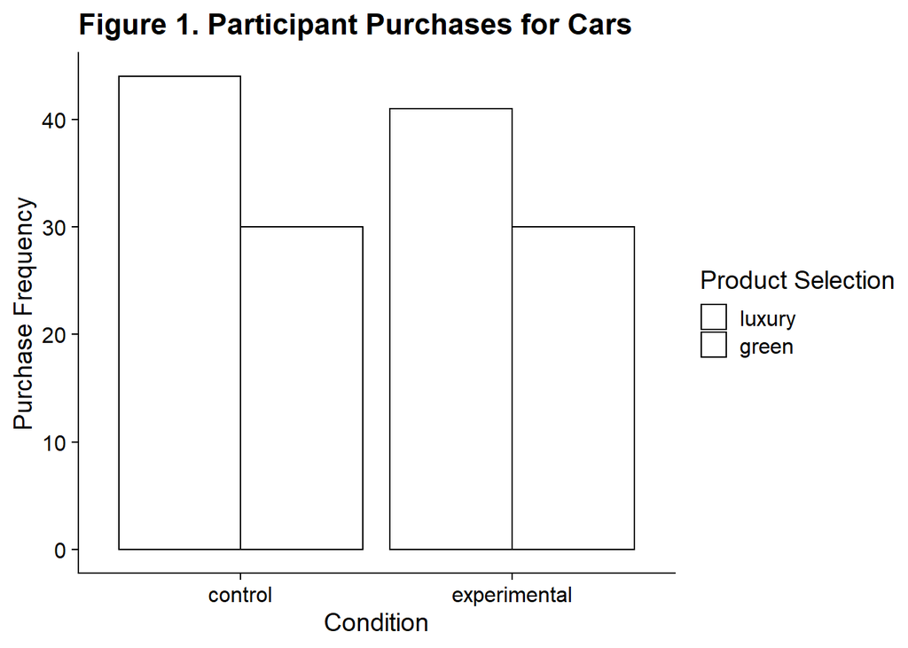

Table 5 *Observed Frequency of Green or Non-Green Dishwashers Bought, by Condition*

|  | Control | Experimental |
| --- | --- | --- |
| luxury | 52 | 33 |
| green | 21 | 38 |

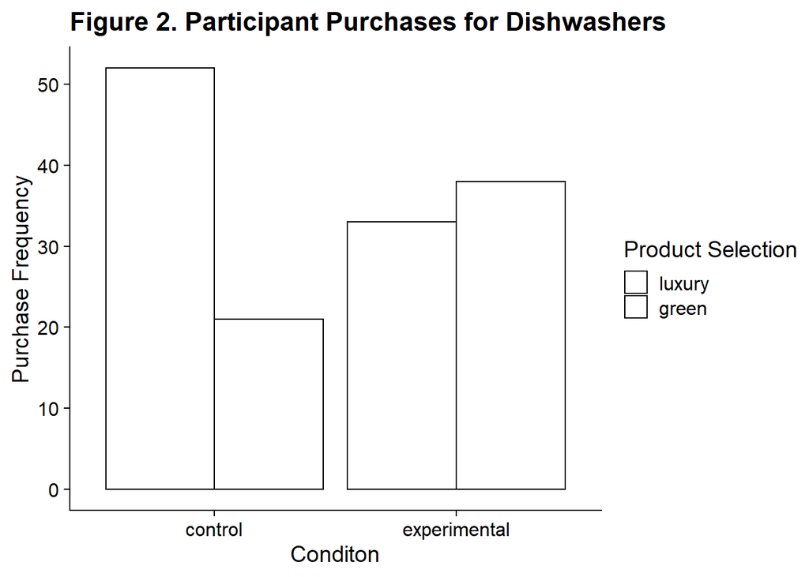

Table 6 *Observed Frequency of Green or Non-Green Cleaners Bought, by Condition*

|  | Control | Experimental |
| --- | --- | --- |
| luxury | 48 | 34 |
| green | 26 | 37 |

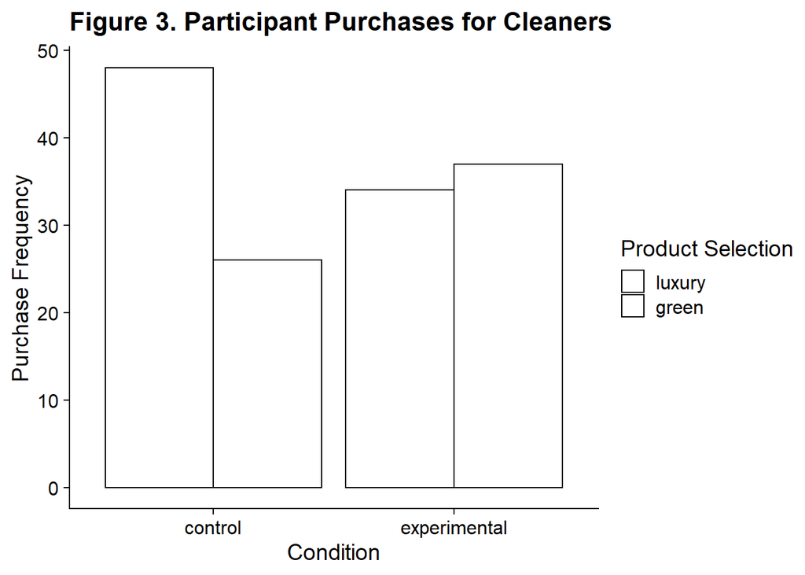

# Discussion

A study conducted by Sundie et al. (Sundie, 2011) investigated perceptions of people who engage in conspicuous consumption; consuming luxuries to enhance one’s prestige. They found a significant relationship under the null hypothesis, with a *p*-value of only 0.08 in men desiring long-term mating, so the null was accepted This shows a similar pattern to my results in that it highlights that the choice for luxury or non-luxury products is governed by people feeling a need to make a statement about themselves, this is the same concept was in my research, albeit a different statement being made. Both studies show that motivations outside of owning a particular product contribute to the choice between two options. Moreover, our results are similar in that Sundie et al.’s results show that there is not a significant relationship between a luxury product choice and mating-motivations; meanwhile my results highlight no relationship between choosing a green car and status-motivations. Both studies show the same pattern of results, in that there appears to be no relationship between car choices and status, or mating motivations. These patterns highlight how consumers are less likely to opt for green alternatives for more expensive products.

Furthermore, research by Hartmann et al. (Hartmann, 2012) investigated the psychological benefits of choosing green energy brands over other, non-green options. They found that psychological benefits of choosing green energy being stated in adverts did have a significant affect on whether participants chose green energy over alternatives. These results go hand-in-hand with my results in the case of participants choosing green dishwashers over luxury ones. Both studies show the same pattern of results, showing that underlying psychological factors - in the case of my research; this being status motivations, and both highlighting the importance of people wanting to show they are prosocial - play an important role in peoples choices between green and non-green products. The similarities between the results from this study and my own may mean that highlighting the psychological motivations and benefits of choosing green products, may be a valuable method of increasing the frequency of people opting not to buy luxury products, but instead going for green alternatives.

One major limitation of my study is that the participants were all Undergraduate Psychology students at the University of Sussex, and all were relatively young, with a max. age of 28. Due to this, my experiment lacks findings that can be generalised to older members of the population; as their choices may differ in comparison to younger people. As a result, a possible area for future research would be investigating whether peoples attitudes towards choosing green products changed with age, and if it does, how it changes. It is also important to point out that this study was completed in a Western University, and whilst some participants may be from other cultures, the majority of these findings are based around Western students. This may not be a universal concept, and findings may differ from culture to culture.

On the other hand, one strength if this research is that it had a relatively even amount of participants that were male and female, meaning the results are generalisable to these two genders. However, the number of participants who identified as anything other than male or female was significantly lower, so, the results may be less generalisable to these members of the population.

One final limitation of this study is that it focuses on the hypothetical choice between green or non-green products, rather than the actual purchasing of the products. Due to this, demand characteristics could have come into play within this research. Some participants may have stated that they would choose green products over luxury just to seem prosocial, when; if they were put into an actual situation where they were buying these products, they may have made a different decision, or to provide the result that they thought the research was looking for. This may have decreased the validity of my findings.

I do think that the effect of high status on people’s motivation to buy green products is real, however it may be much more forefronted when it comes to cheaper goods. Also, I think there is many different opportunities for further research within this field, including;

- how age affects people’s attitudes towards green products, and how this impacts choices between green and non-green products, as previously mentioned
- as well as further research into how the base-cost of products affects peoples likelihood of choosing green options, and how to increase the frequency of green alternatives being chosen over non-green luxury products.

In conclusion, my findings showed no significant relationship between high-status motives and purchases of green cars and cleaners over non-green alternatives. But, I also found that people are influenced by high-status motives when buying dishwashers, which was concurrent with results from the original study by Griskevicius et al. in 2010. The main take-away from this research is that people choose green products based on a desire to make a statement about their own prosocial behaviours, however, the average cost of these products and the age of participants may have important impacts on how significant the relationship between high-status motives and green purchases is on people’s choices. Further research needs to be conducted in order to fully understand the impact of these third-party factors and, if necessary, how to mitigate against them.

# References

Griskevicius, V., Van den Bergh, B., & M. Tybur, J. (2010). *Going green to Be Seen: Status, Reputation, and Conspicuous Conservation*.

Hartmann, P., & Apaolaza-Ibáñez, V. (2012). *Consumer attitude and purchase intention toward green energy brands: The roles of psychological benefits

and environmental concern*. Journal of Business Research, 65(9), 1254–1263. https://doi.org/10.1016/j.jbusres.2011.11.001

Sundie, J. M., Kendrick, D. T., & et, al. (2011). *Peacocks, Porsches, and Thorstein Veblen: Conspicuous Consumption as a Sexual Signaling System*.